# # Exploring White Wine Quality by Ursula Neumann

```
##   fixed.acidity volatile.acidity citric.acid residual.sugar chlorides
## 1           7.0             0.27        0.36           20.7     0.045
## 2           6.3             0.30        0.34            1.6     0.049
## 3           8.1             0.28        0.40            6.9     0.050
## 4           7.2             0.23        0.32            8.5     0.058
## 5           7.2             0.23        0.32            8.5     0.058
## 6           8.1             0.28        0.40            6.9     0.050
##   free.sulfur.dioxide total.sulfur.dioxide density   pH sulphates alcohol
## 1                  45                  170  1.0010 3.00      0.45     8.8
## 2                  14                  132  0.9940 3.30      0.49     9.5
## 3                  30                   97  0.9951 3.26      0.44    10.1
## 4                  47                  186  0.9956 3.19      0.40     9.9
## 5                  47                  186  0.9956 3.19      0.40     9.9
## 6                  30                   97  0.9951 3.26      0.44    10.1
##   quality
## 1       6
## 2       6
## 3       6
## 4       6
## 5       6
## 6       6
```

# Introduction

This dataset, originally described by [Cortez et al. 2009](https://www.sciencedirect.com/science/article/pii/S0167923609001377) contains 4,898 white wines with 11 variables quantifying the chemical properties of each wine. At least 3 wine experts rated the quality of each wine, providing a rating between 0 (very bad) and 10 (very excellent). [This link](https://s3.amazonaws.com/udacity-hosted-downloads/ud651/wineQualityInfo.txt) describes of the variables and how the data was collected. I am interested in investigating which chemical properties influence the quality of white wines.

# Univariate Plots Section

```
## [1] 4898   12
```

As expected there are 4898 white wines, with 12 columns (11 physicochemical properties and 1 quality rating).

```
## 'data.frame':    4898 obs. of  12 variables:
##  $ fixed.acidity       : num  7 6.3 8.1 7.2 7.2 8.1 6.2 7 6.3 8.1 ...
##  $ volatile.acidity    : num  0.27 0.3 0.28 0.23 0.23 0.28 0.32 0.27 0.3 0.22 ...
##  $ citric.acid         : num  0.36 0.34 0.4 0.32 0.32 0.4 0.16 0.36 0.34 0.43 ...
##  $ residual.sugar      : num  20.7 1.6 6.9 8.5 8.5 6.9 7 20.7 1.6 1.5 ...
##  $ chlorides           : num  0.045 0.049 0.05 0.058 0.058 0.05 0.045 0.045 0.049 0.044 ...
##  $ free.sulfur.dioxide : num  45 14 30 47 47 30 30 45 14 28 ...
##  $ total.sulfur.dioxide: num  170 132 97 186 186 97 136 170 132 129 ...
##  $ density             : num  1.001 0.994 0.995 0.996 0.996 ...
##  $ pH                  : num  3 3.3 3.26 3.19 3.19 3.26 3.18 3 3.3 3.22 ...
##  $ sulphates           : num  0.45 0.49 0.44 0.4 0.4 0.44 0.47 0.45 0.49 0.45 ...
##  $ alcohol             : num  8.8 9.5 10.1 9.9 9.9 10.1 9.6 8.8 9.5 11 ...
##  $ quality             : int  6 6 6 6 6 6 6 6 6 6 ...
```

All of the 11 physicochemical properties are of the numeric type (contains decimals) while the quality values are integers.

```
##  fixed.acidity    volatile.acidity  citric.acid     residual.sugar
##  Min.   : 3.800   Min.   :0.0800   Min.   :0.0000   Min.   : 0.600
##  1st Qu.: 6.300   1st Qu.:0.2100   1st Qu.:0.2700   1st Qu.: 1.700
##  Median : 6.800   Median :0.2600   Median :0.3200   Median : 5.200
##  Mean   : 6.855   Mean   :0.2782   Mean   :0.3342   Mean   : 6.391
##  3rd Qu.: 7.300   3rd Qu.:0.3200   3rd Qu.:0.3900   3rd Qu.: 9.900
##  Max.   :14.200   Max.   :1.1000   Max.   :1.6600   Max.   :65.800
##    chlorides       free.sulfur.dioxide total.sulfur.dioxide
##  Min.   :0.00900   Min.   :  2.00      Min.   :  9.0
##  1st Qu.:0.03600   1st Qu.: 23.00      1st Qu.:108.0
##  Median :0.04300   Median : 34.00      Median :134.0
##  Mean   :0.04577   Mean   : 35.31      Mean   :138.4
##  3rd Qu.:0.05000   3rd Qu.: 46.00      3rd Qu.:167.0
##  Max.   :0.34600   Max.   :289.00      Max.   :440.0
##     density             pH          sulphates         alcohol
##  Min.   :0.9871   Min.   :2.720   Min.   :0.2200   Min.   : 8.00
##  1st Qu.:0.9917   1st Qu.:3.090   1st Qu.:0.4100   1st Qu.: 9.50
##  Median :0.9937   Median :3.180   Median :0.4700   Median :10.40
##  Mean   :0.9940   Mean   :3.188   Mean   :0.4898   Mean   :10.51
##  3rd Qu.:0.9961   3rd Qu.:3.280   3rd Qu.:0.5500   3rd Qu.:11.40
##  Max.   :1.0390   Max.   :3.820   Max.   :1.0800   Max.   :14.20
##     quality
##  Min.   :3.000
##  1st Qu.:5.000
##  Median :6.000
##  Mean   :5.878
##  3rd Qu.:6.000
##  Max.   :9.000
```

For all variables the median and the mean are close together suggesting that these parameters will not be highly skewed. The median (5.2) and mean (6.3) of the residual sugar variable are the farthest apart suggesting that there may be some outliers on the high end (for example the max of 65.8). It is surprising to observe a fold difference of over 100 between the minimum and maximum values for residual sugar and free sulfur dioxide. The alcohol content ranges from 8.0 - 14.2%. The scale for quality was 1-10; however, the ratings given only range from 3-9, with a median rating of 6.

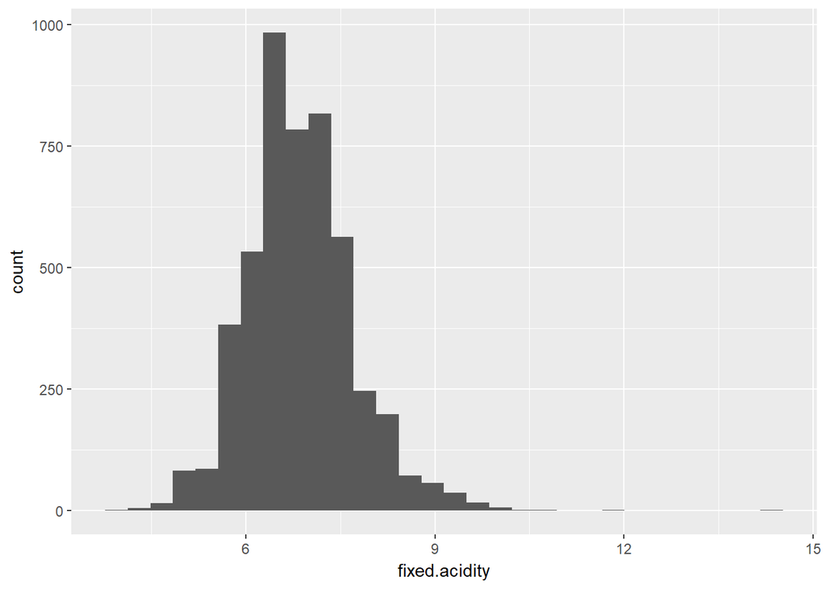

The histogram of fixed acidity appears to be normally distributed.

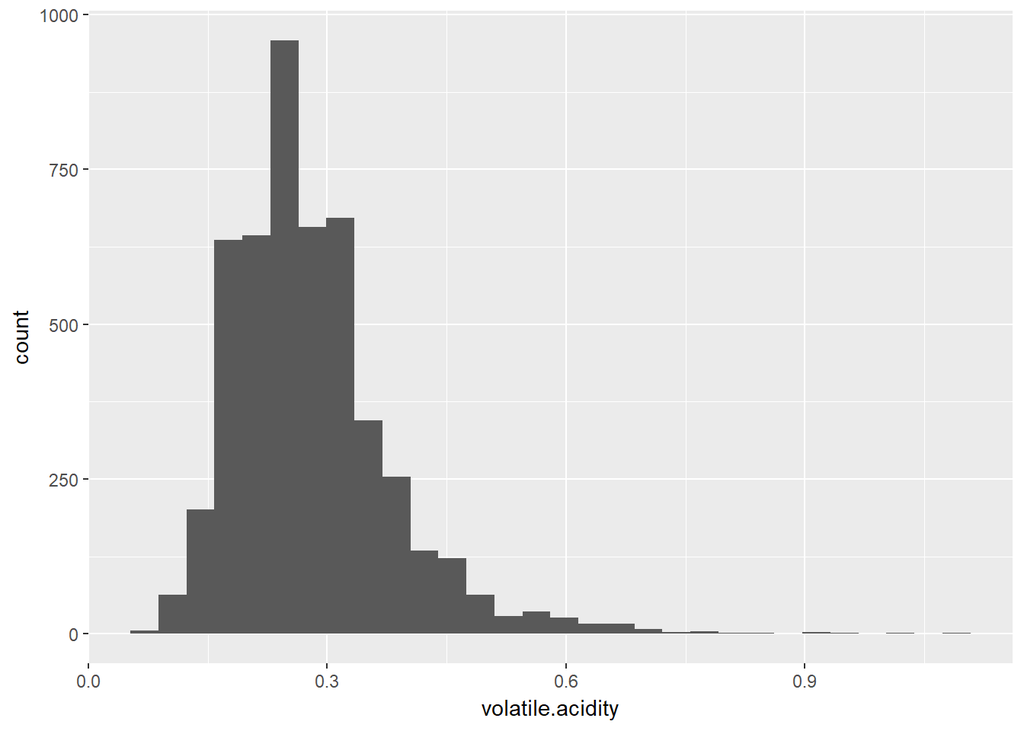

The histogram of volatile acidity is slightly skewed to the right. I will log10 transform this data to see if it makes the histogram normally distributed.

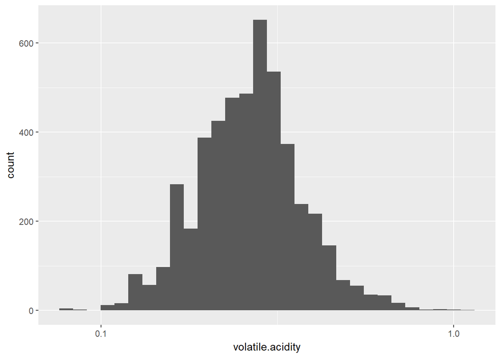

Now volatile acidity is normally distributed.

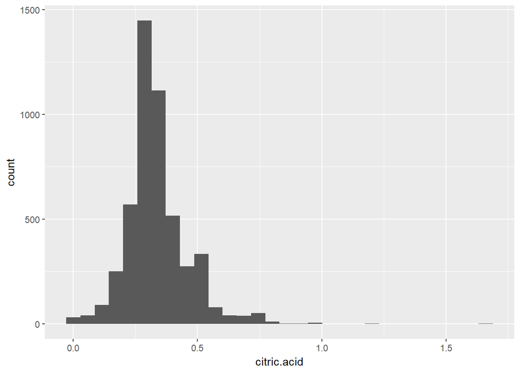

The bulk of the data of citric acid is normally distributed with an outlier of 1.66 pulling the skew to the right.

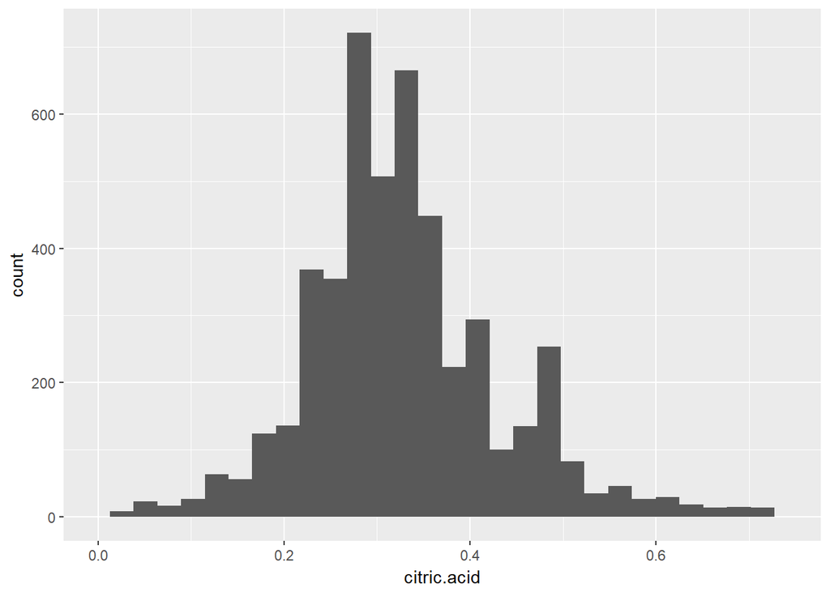

When the top 1% of citric acid data is removed the data appear normally distributed.

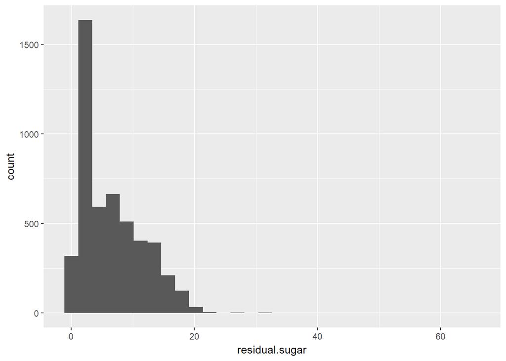

The histogram of residual sugar is skewed to the right. This graph has the bin with the highest count near the left with a wide right tail and an outlier at 65.8.

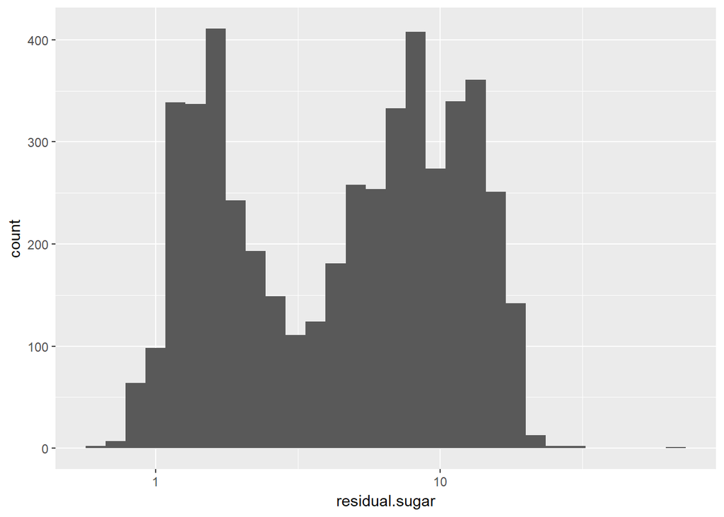

Transforming the data using a log10 scale does not make the data normally distributed, but bimodal.

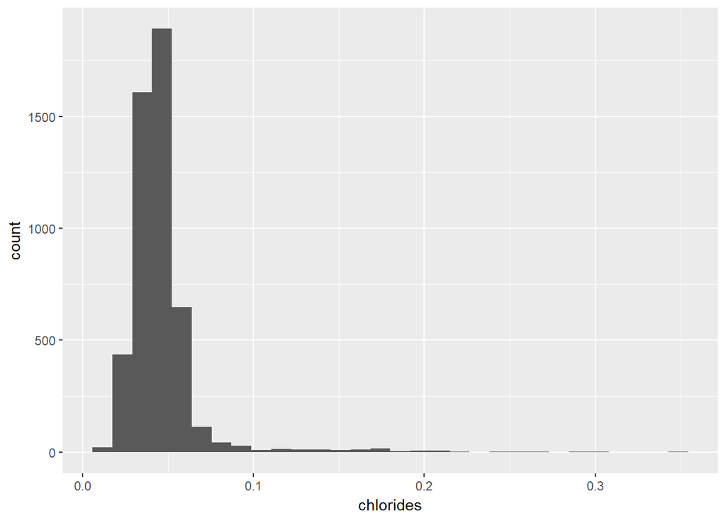

The histogram of chlorides is skewed to the right with a long thin tail.

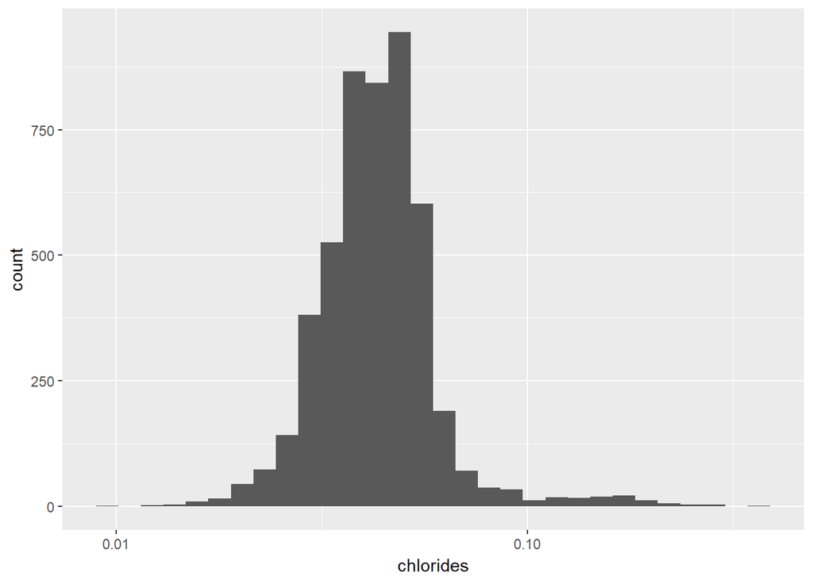

Transforming the chlorides data using log10 makes the data appear more normally distributed.

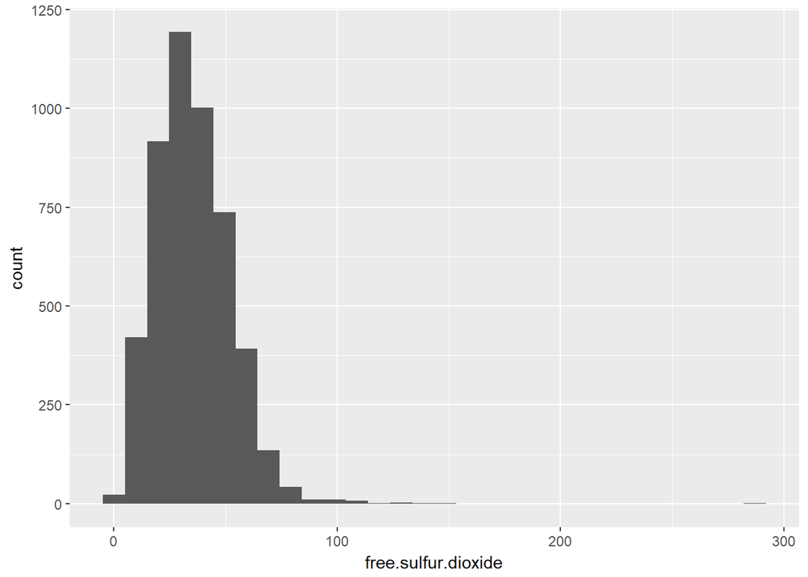

The histogram of free sulfur dioxide levels appears to be slightly skewed to the right with a very small and thin tail and an outlier at 289.

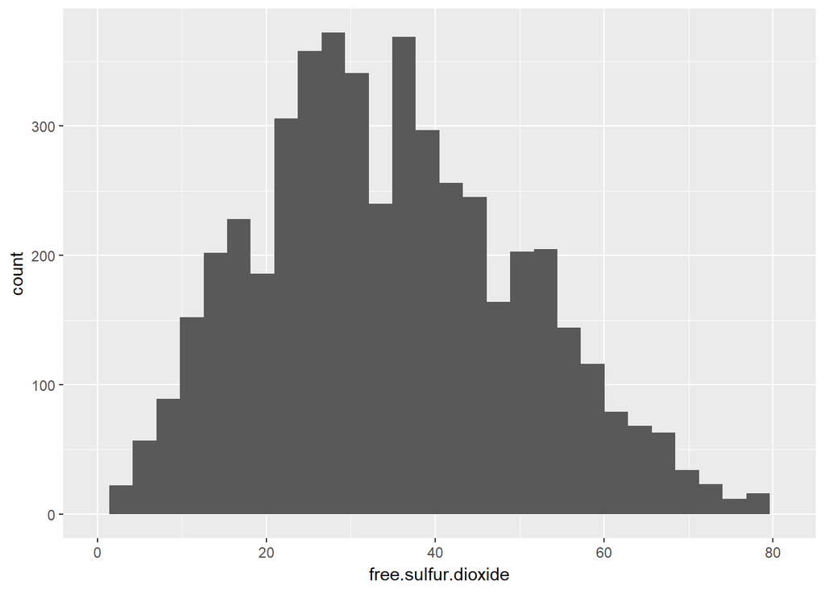

When excluding the top 1% of free sulfur dioxide levels, the data appear more symmetric, however, the data looks more like a pyramid instead of normally distributed.

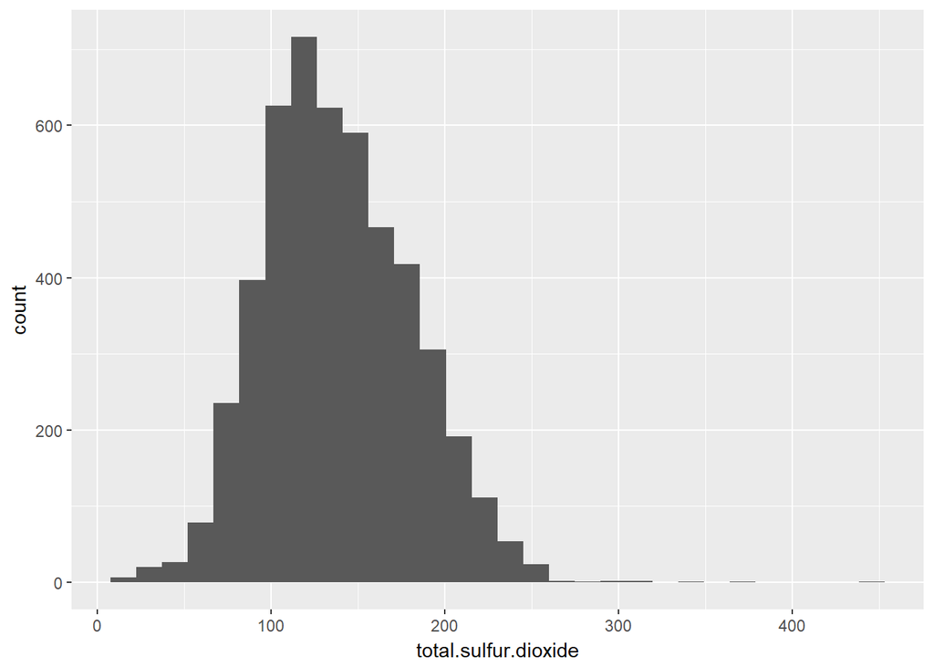

The histogram of total sulfur dioxide generally looks normally distributed with an extremely thin right tail.

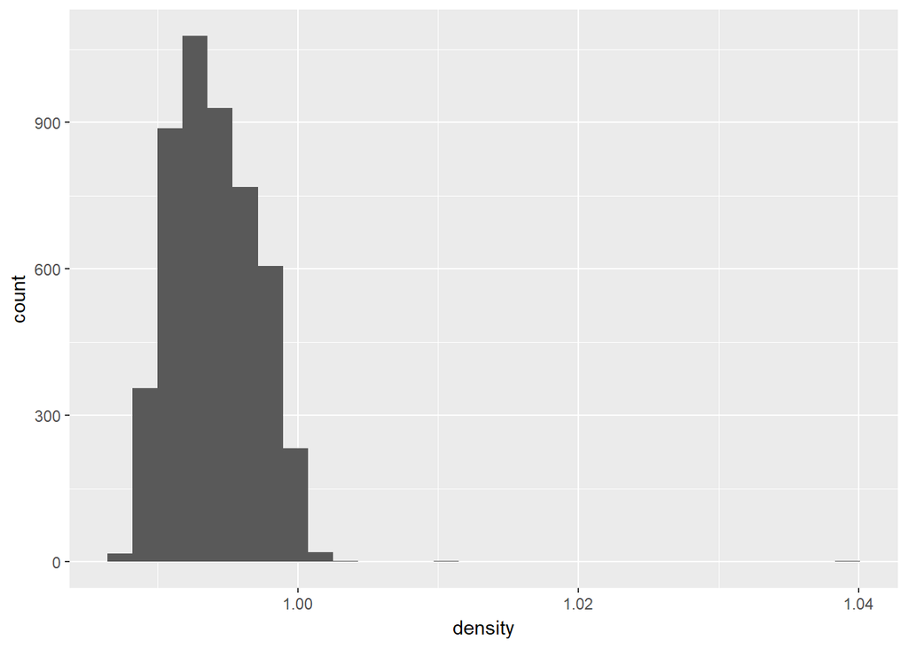

The histogram of density appears to be normally distributed with a very thin right tail and an outlier at 1.039. The majority of densities are close to, but below, 1 which makes sense given the density of water being 1 and alcohol being less than 1. I’m unsure what would cause a wine to have a density above 1.

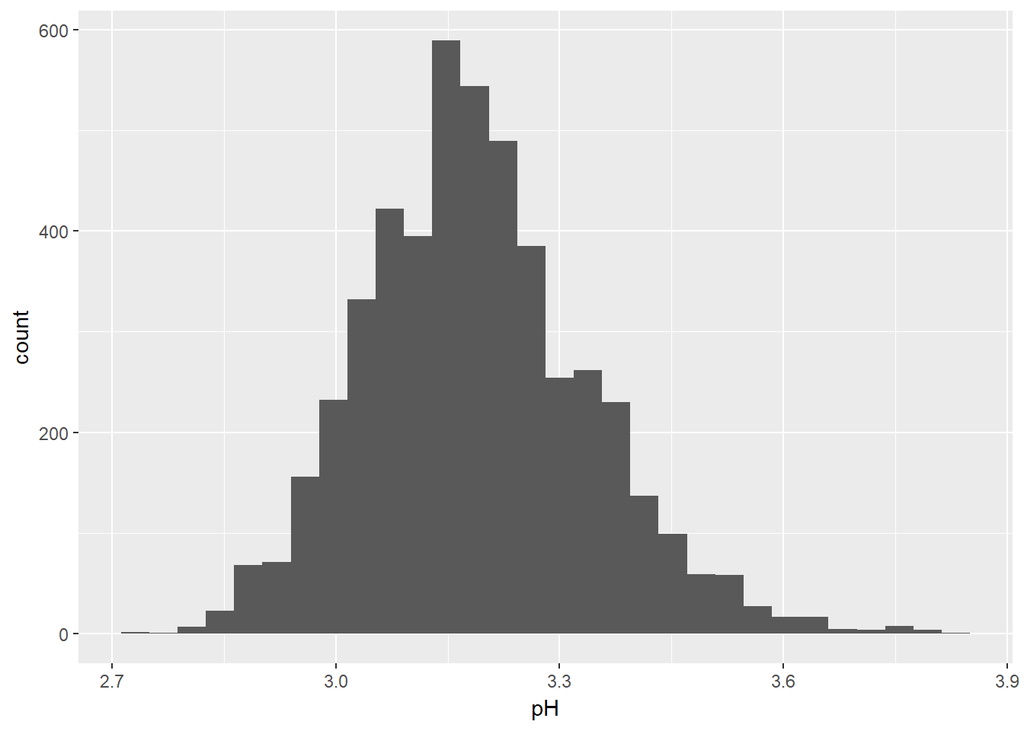

The histogram of pH appears to be normally distributed.

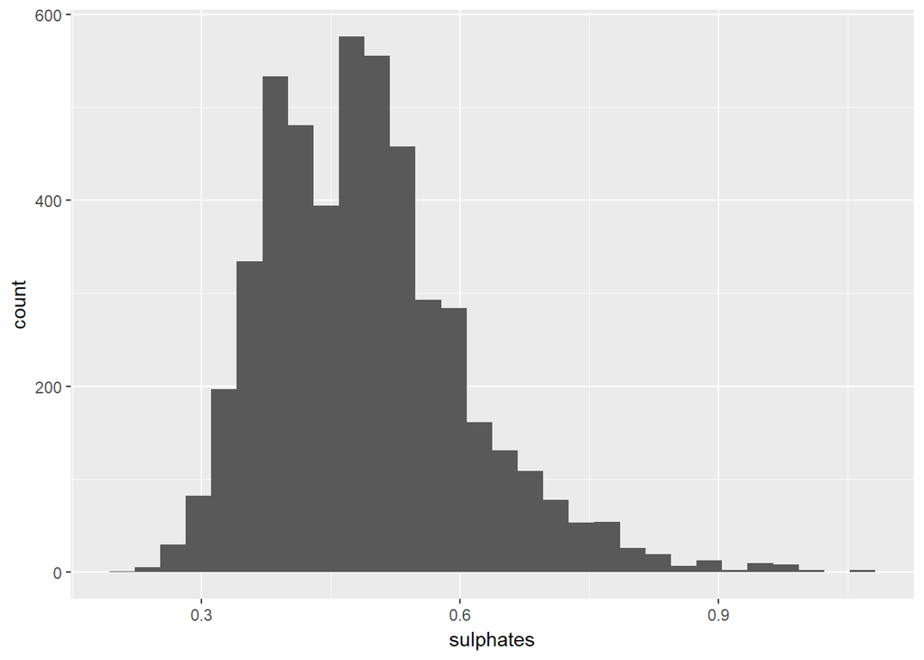

The histogram of sulphates appears to be skewed to the right.

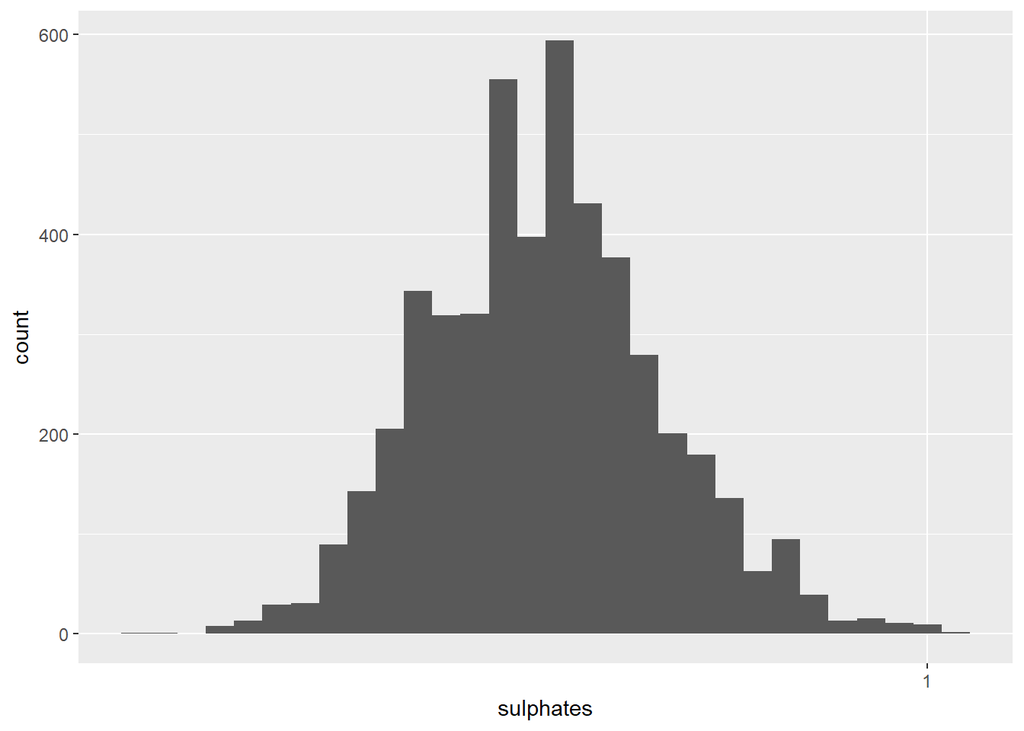

Graphing sulphates on a log10 scale transforms the data to be normally distributed.

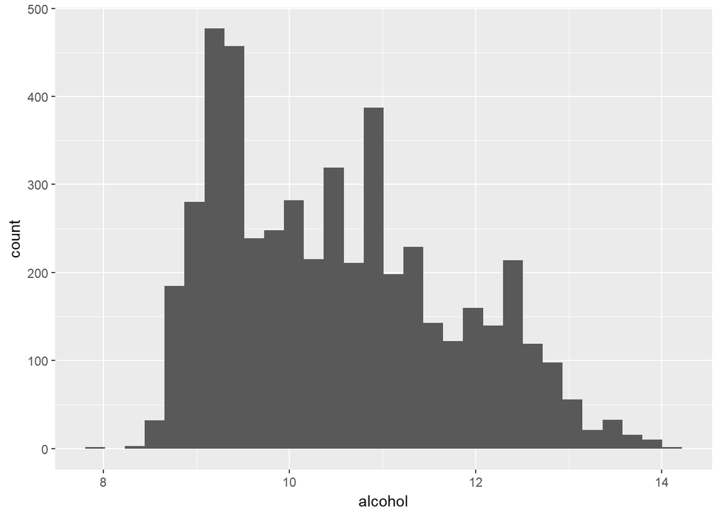

The histogram of alcohol levels is skewed to the right with a wide tail.

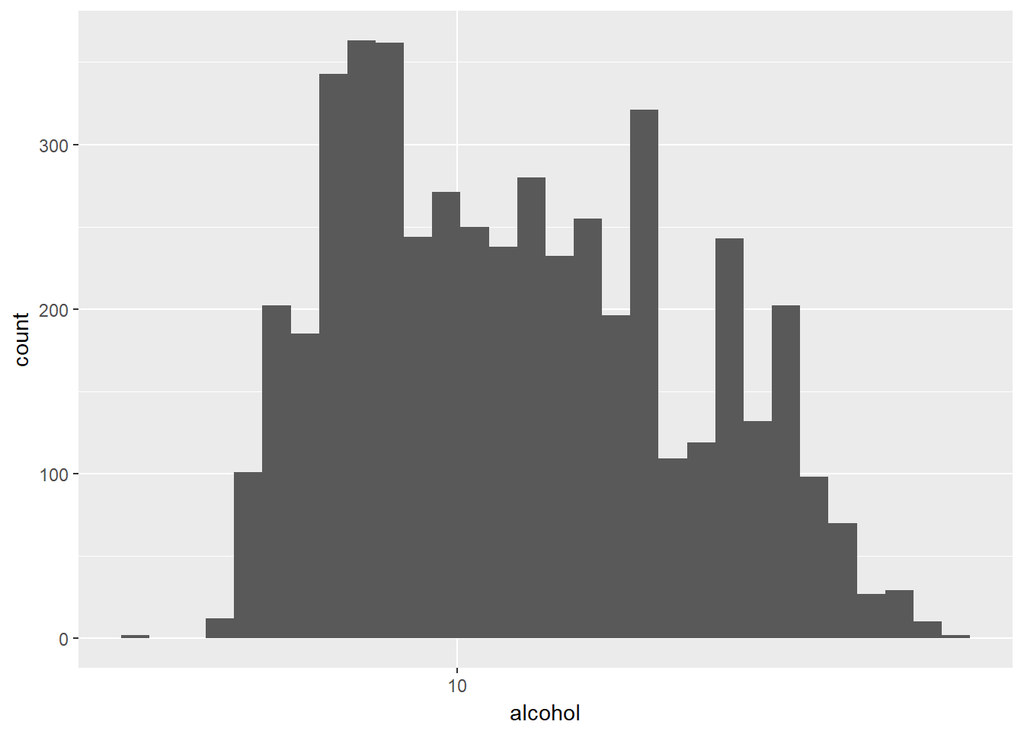

Graphing the alcohol data on a log10 scale makes the data more symmetric but does not appear normally distributed as the peak of the data is wide.

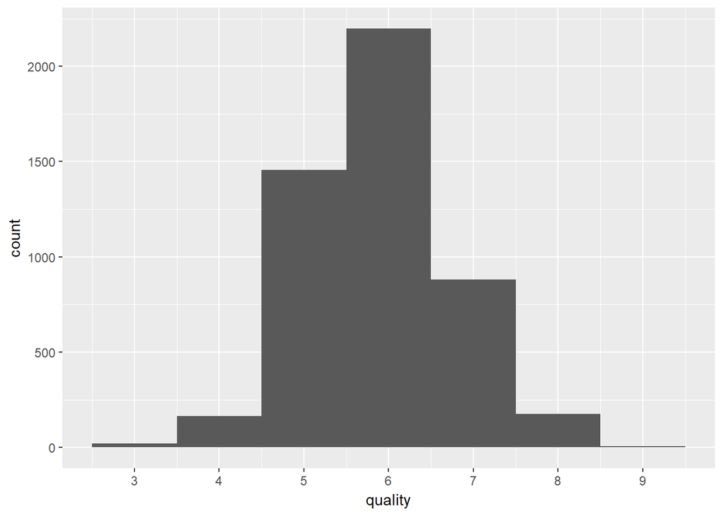

The quality rating with the highest count is 6 and the data are largely symmetric as the ratings for 5 and 7 are slightly lower, 4 and 8 are even lower, 3 and 9 are very low, and 0, 1, 2 and 10 are absent.

# Univariate Analysis

### What is the structure of your dataset?

The dataset contains data on 4898 white wines with 12 columns (11 physicochemical properties and 1 quality rating). All of the 11 physicochemical properties are of the numeric type (contains decimals) while the quality values are integers.

### What is/are the main feature(s) of interest in your dataset?

I would like to investigate which physicochemical properties of the wine influence the quality rating; therefore, the quality rating is the most important feature in this data.

### What other features in the dataset do you think will help support your investigation into your feature(s) of interest?

I will investigate all 11 properties of the wines to determine whether they influence quality. Given my limited knowledge of wine and these specific physicochemical properties, I cannot predict which features will affect quality. In addition, the univariate analyses alone does not shed light on which variables will be the most important therefore I will investigate them all in the bivariate section.

### Did you create any new variables from existing variables in the dataset?

I have not created any new variables yet. This may change after further investigation into the bi- and multi-variate analyses.

### Of the features you investigated, were there any unusual distributions? Did you perform any operations on the data to tidy, adjust, or change the form of the data? If so, why did you do this?

The data was already tidy therefore no adjustments were made.

# Bivariate Plots Section

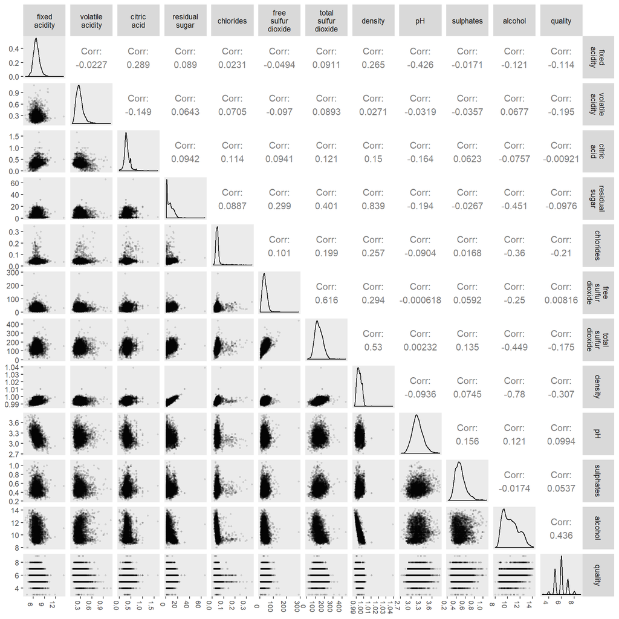

Although I am most interested in determining if any of these physicochemical properties influence quality, we will investigate all relationships first to better understand the data. I will report on correlations that are equal to or greater than |0.3| when rounded to 1 decimal point with correlations between |0.3| and |0.7| to be considered moderate and above |0.7| to be strong.

It is logical that fixed acidity would be positively correlated to citric acid and negatively correlated to pH given each that each parameter is related to acidity.

Interestingly density and alcohol were correlated to many other parameters. It makes sense that density would increase with increasing solutes (residual sugar, chlorides, etc.) but I’m assuming that because density decreases with increasing alcohol levels (given the density of alcohol vs water) this explains why alcohol is therefore negatively correlated to these solutes as well.

The only parameters that are related to quality are alcohol (which are moderately positive correlated), and density (which are moderately negative correlated).

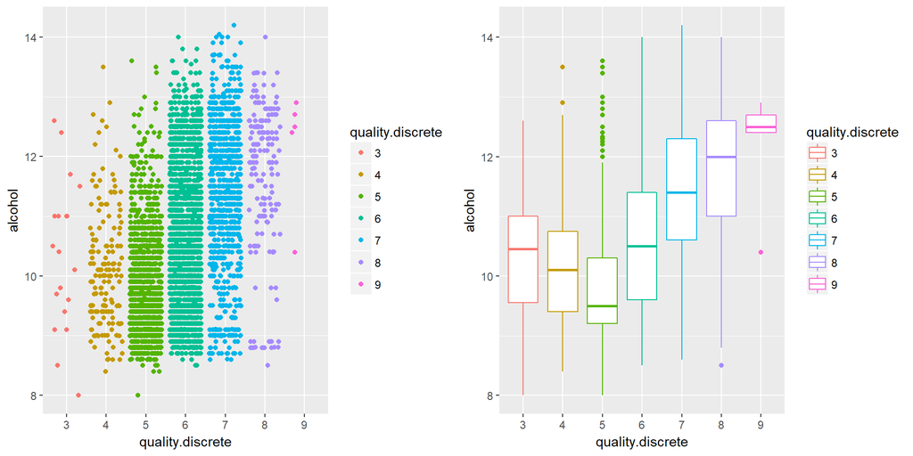

In the graph on the left we can see that the majority of the data falls in quality rating 5, 6 and 7, less data falls in a rating of 4 and 8, even less so in the rating of 3, and only five points in a rating of 9. There is a great deal of overlap between each sequential rating.

Interestingly, in the graph on the right, it looks like the alcohol rating tends to decrease from a quality rating of 3 to 5, and increases from 5 to 9. The group with the least variability is the quality rating of 9 where 80% of the points are clustered together at a high alcohol rating. However, there is  
a very low N (only 5 observations in this category), and variability may increase with more observations.

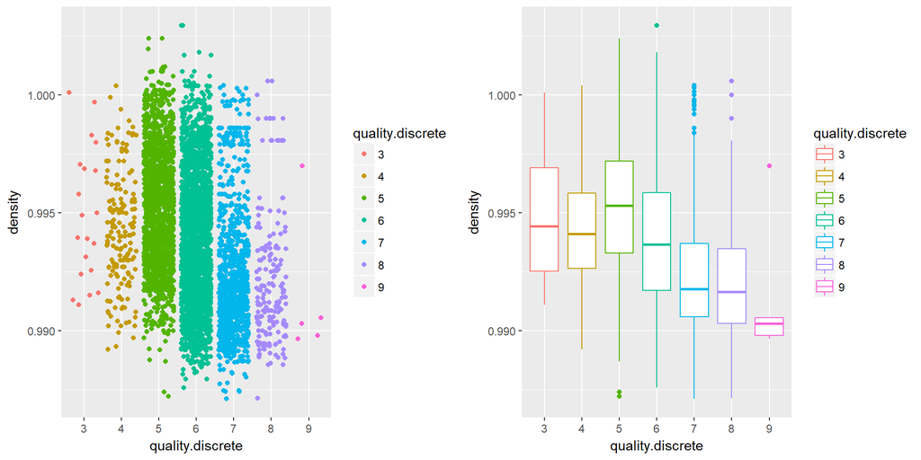

Similar to the alcohol vs quality plots, the density vs quality plots also exhibit significant overlap between the quality groups. Because density and alcohol are related (increased alcohol leads to decreased density), again we observe the least variability in the group with a quality rating of 9 where 80% of the points are clustered together at a low density level.

So far it does not appear that either alcohol or density (or anything else) are strong indicators of quality. Therefore, to investigate the strongest correlation observed I will graph density vs alcohol.

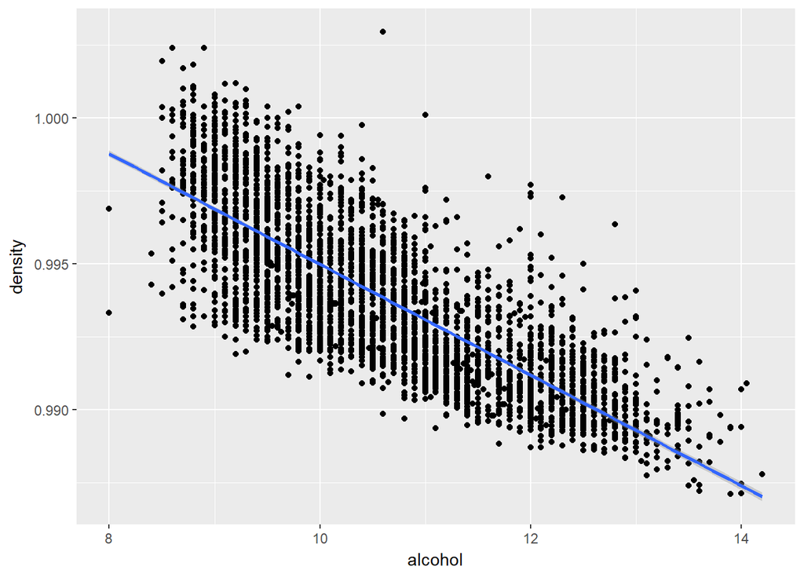

This indeed is a stronger relationship. Again this is not surprising given that alcohol is less dense than water. However, I anticipate that predicting density (rather than qulity) will end up being more fruitful using predictive models, albeit potentially less interesting.

# Bivariate Analysis

### Talk about some of the relationships you observed in this part of the investigation. How did the feature(s) of interest vary with other features in the dataset?

Using the scatterplot matrix I was able to quickly observe the correlations between all variables. It was not surprising that fixed acidity was positively correlated to citric acid and negatively correlated to pH given each that each parameter is related to acidity. In addition, free and total sulfur dioxide levels are strongly positively correlated to one another since total levels are equal to free levels + bound levels of sulfur dioxide.

Unfortunately, alcohol and density were only weakly to moderately correlated to quality (0.4 and -0.3 respectively), and therefore I do not anticipate that the predictive model I will generate in the next section will be very accurate.

### Did you observe any interesting relationships between the other features (not the main feature(s) of interest)?

What was more interesting to me was the relationship between density and alcohol, as well as the relationship between each of these parameters to fixed acidity, residual sugar, chlorides, and total sulfur dioxide levels. I anticipate that the predictive model generated for predicting density will be more accurate than the one predicting quality.

### What was the strongest relationship you found?

The strongest relationships found were density vs residual sugar (0.8) and density vs alcohol (-0.8).

# Multivariate Plots Section

I am first going to attempt to make a predictive model for quality. Quality was most strongly correlated to alcohol and I would like to see if any other variables help explain the variability seen in the quality vs alcohol graph.

```
##    Low Medium   High
##   1715   1383   1800
```

For all instances of me dividing up variables into 3 roughly equal-sized groups, I chose the values manually as I was curious to play around with the numbers; however, I believe there is also a easy to cut them into 3 equal groups automatically.

For the colors chosen, I first experimented using the color scale brewer code using a sequential color scheme because the data is ordinal. For all 3 color combinations (including that for the Blues which I wanted to use), the lightest color was too light and could barely be seen above the white or gray background of the plots. Therefore, I went to the colorbrewer2.org website where I could experiment with the color choices. I used the 7-Class Blues and picked color 3, 5 and 7, as I found these distinct enough from each other, yet the lightest color was still visible on the gray background. These colors were then manually added using scale_color_manual. This method is used throughout this section however I have used scale_color_brewer in the final plot section to illustrate that I know how to use it.

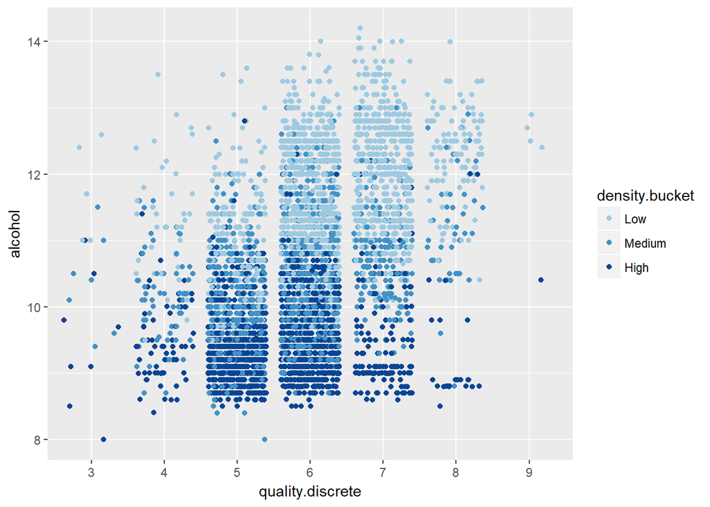

Density appears to be more correlated to alcohol levels alone. Next, I will look at the residual sugar level, which was highly correlated to density (which was moderately correlated to quality).

```
##    Low Medium   High
##   1500   1776   1622
```

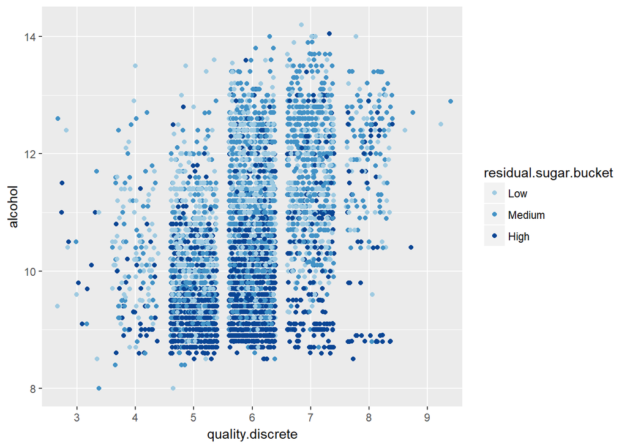

The different colored points (varied residual sugar levels) appear to be equally distributed throughout the plot and therefore likely do not explain the variability observed.

For curiosity’s sake I will generate a predictive model incorporating alcohol first, then adding on other variables to see their effect on the R-squared value of the model. However, I anticipate that the model will be very poor.

```
##
## Calls:
## m1: lm(formula = I(quality) ~ I(alcohol), data = df)
## m2: lm(formula = I(quality) ~ I(alcohol) + density, data = df)
## m3: lm(formula = I(quality) ~ I(alcohol) + residual.sugar, data = df)
## m4: lm(formula = I(quality) ~ I(alcohol) + chlorides, data = df)
## m5: lm(formula = I(quality) ~ I(alcohol) + density + residual.sugar,
##     data = df)
## m6: lm(formula = I(quality) ~ I(alcohol) + density + residual.sugar +
##     chlorides, data = df)
##
## ======================================================================================================
##                        m1            m2            m3            m4            m5            m6
## ------------------------------------------------------------------------------------------------------
##   (Intercept)         2.582***    -22.492***      2.021***      2.861***     90.313***     87.563***
##                      (0.098)       (6.165)       (0.117)       (0.116)      (12.374)      (12.392)
##   I(alcohol)          0.313***      0.360***      0.354***      0.298***      0.246***      0.237***
##                      (0.009)       (0.015)       (0.010)       (0.010)       (0.018)       (0.018)
##   density                          24.728***                                -87.886***    -84.931***
##                                    (6.079)                                  (12.317)      (12.340)
##   residual.sugar                                  0.022***                    0.053***      0.052***
##                                                  (0.002)                     (0.005)       (0.005)
##   chlorides                                                    -2.471***                   -1.776**
##                                                                (0.558)                     (0.555)
## ------------------------------------------------------------------------------------------------------
##   R-squared           0.190         0.192         0.202         0.193         0.210         0.212
##   adj. R-squared      0.190         0.192         0.202         0.193         0.210         0.211
##   sigma               0.797         0.796         0.791         0.796         0.787         0.787
##   F                1146.395       583.290       619.354       585.182       434.085       328.736
##   p                   0.000         0.000         0.000         0.000         0.000         0.000
##   Log-likelihood  -5839.391     -5831.127     -5802.158     -5829.599     -5776.812     -5771.696
##   Deviance         3112.257      3101.773      3065.298      3099.838      3033.737      3027.406
##   AIC             11684.782     11670.255     11612.317     11667.199     11563.624     11555.391
##   BIC             11704.272     11696.241     11638.303     11693.185     11596.107     11594.371
##   N                4898          4898          4898          4898          4898          4898
## ======================================================================================================
```

m1 using alcohol alone as a predicter elicited a R-squared value of only 0.190. Adding on density, residual sugar, and chlorides alone increased the R-squared value minutely. m6 using all of these parameters had the highest R-squared value of 0.212 which is still a very poor model. Again, out of curiosity I wanted to determine how large the 95% confidence intervals would be when predicting a wine with the median value for all variables, as well as a wine with a quality rating of 9.

```
##        fit     lwr      upr
## 1 5.822158 4.27991 7.364405
```

For the median wine which would have a rating of ~6, the estimate of 5.8 is not that far off.

```
##      fixed.acidity volatile.acidity citric.acid residual.sugar chlorides
## 775            9.1             0.27        0.45           10.6     0.035
## 821            6.6             0.36        0.29            1.6     0.021
## 828            7.4             0.24        0.36            2.0     0.031
## 877            6.9             0.36        0.34            4.2     0.018
## 1606           7.1             0.26        0.49            2.2     0.032
##      free.sulfur.dioxide total.sulfur.dioxide density   pH sulphates
## 775                   28                  124 0.99700 3.20      0.46
## 821                   24                   85 0.98965 3.41      0.61
## 828                   27                  139 0.99055 3.28      0.48
## 877                   57                  119 0.98980 3.28      0.36
## 1606                  31                  113 0.99030 3.37      0.42
##      alcohol quality quality.discrete density.bucket residual.sugar.bucket
## 775     10.4       9                9           High                  High
## 821     12.4       9                9            Low                   Low
## 828     12.5       9                9            Low                   Low
## 877     12.7       9                9            Low                Medium
## 1606    12.9       9                9            Low                Medium
```

```
##        fit     lwr      upr
## 1 5.834471 4.29174 7.377201
```

When qualities of a highly rated (quality 9) wine are inputted into the model, the estimate is identical to before, a value of only 5.8 and a value of 9 did not fall within the 95% confidence interval. I expect for any parameters that are inputted into the model, it will predict the same quality and thus is a very poor model.

Moving away from quality, would like to try and predict the density of wine based on the alcohol levels, as well as additional parameters starting with residual sugar. For each variable I have graphed a plot with a single line linear line over all the data (I find this is easier to look at all the points and see trends in the colors) as well as a linear line for each bucket being used to color the data (which can then show any differences in the relationship due to that parameter).

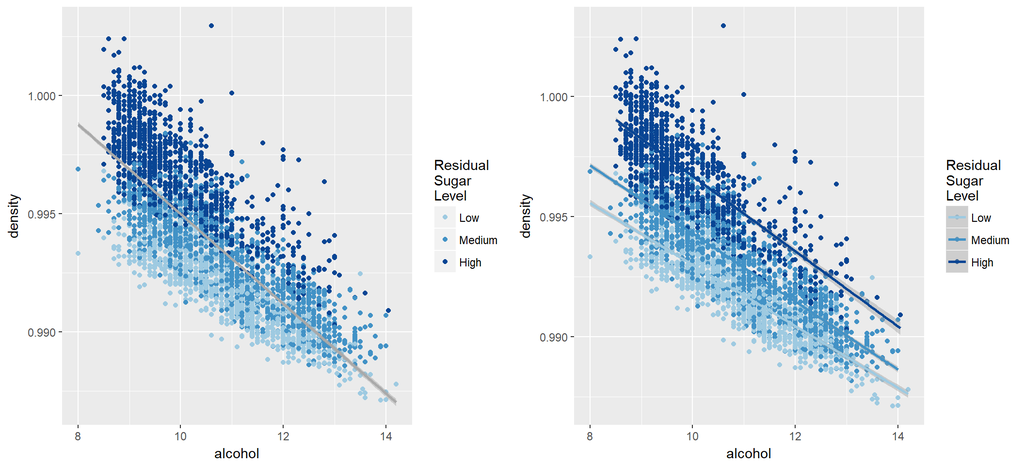

Residual sugar appears to explain some of the variability in the density vs alcohol graph since the points above the linear line of best fit have the highest sugar levels, and the observations below the line contain the lowest sugar levels.

```
##    Low Medium   High
##   1724   1708   1466
```

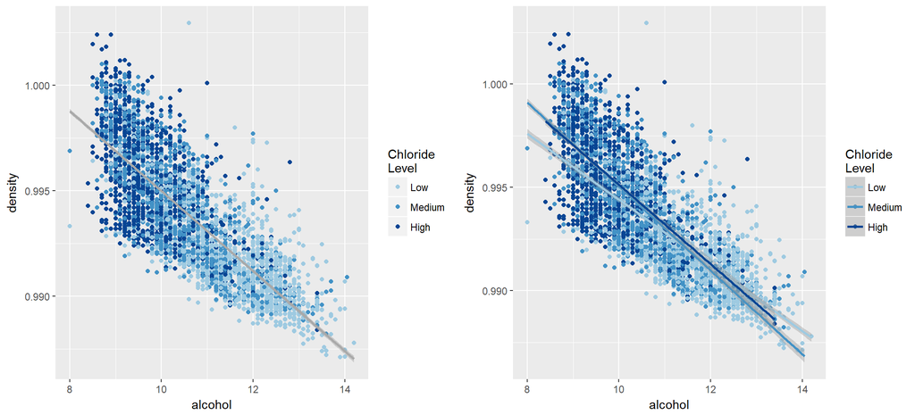

Chlorides do not seem to explain the variability in the density vs alcohol plot since the color shift seems to be more related to alcohol levels alone.

```
##    Low Medium   High
##   1471   1747   1680
```

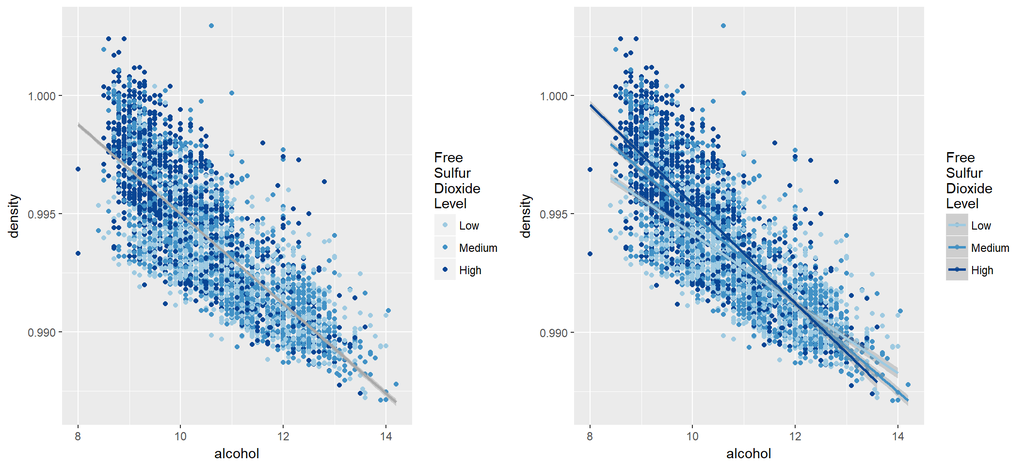

I do not observe any pattern when bucketing by free sulfur dioxide levels.

```
##    Low Medium   High
##   1579   1691   1628
```

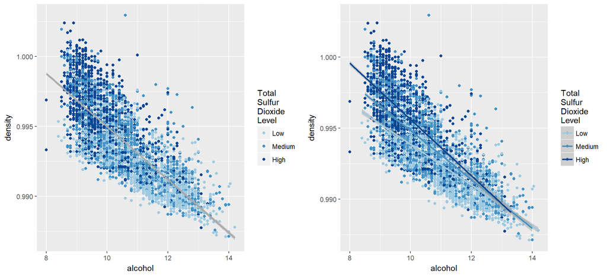

It is difficult to say whether total sulfur dioxide levels explain the variability in the density vs alcohol plot. There is a cluster of “high” points on the top left above the linear line of best fit, however, the “low” points seem to congregate at higher alcohol levels both below and above the linear line.

```
##    Low Medium   High
##   1575   1533   1790
```

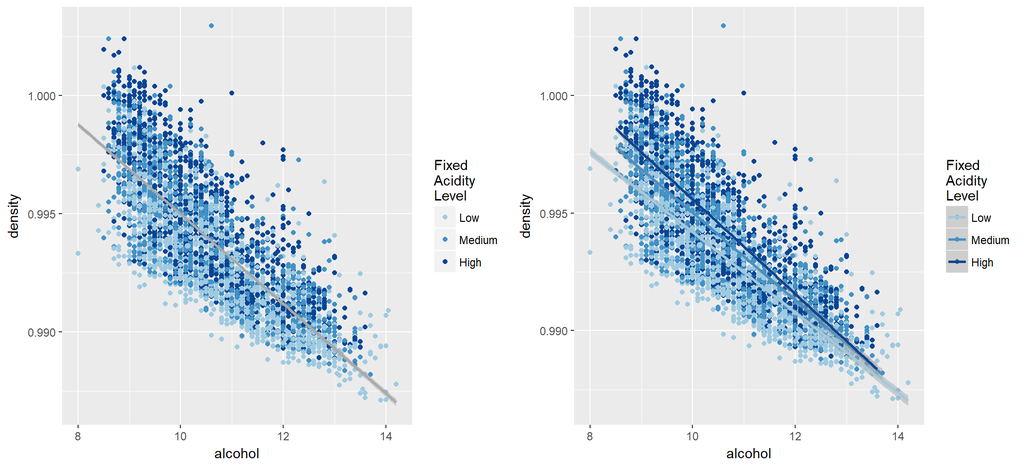

Fixed acidity levels may explain some of the variability in the plot of density vs alcohol since the highest points at any given alcohol level tend to be darker (higher fixed acidity) while the lowest points tend to be the lightest (lowest fixed acidity).

Next I will generate a predictive model of density.

```
##
## Calls:
## m1: lm(formula = I(density) ~ I(alcohol), data = df)
## m2: lm(formula = I(density) ~ I(alcohol) + residual.sugar, data = df)
## m3: lm(formula = I(density) ~ I(alcohol) + residual.sugar + fixed.acidity,
##     data = df)
## m4: lm(formula = I(density) ~ I(alcohol) + residual.sugar + fixed.acidity +
##     chlorides, data = df)
## m5: lm(formula = I(density) ~ I(alcohol) + residual.sugar + fixed.acidity +
##     chlorides + free.sulfur.dioxide, data = df)
## m6: lm(formula = I(density) ~ I(alcohol) + residual.sugar + fixed.acidity +
##     chlorides + free.sulfur.dioxide + total.sulfur.dioxide, data = df)
##
## ==================================================================================================================
##                              m1             m2             m3             m4             m5             m6
## ------------------------------------------------------------------------------------------------------------------
##   (Intercept)                1.014***       1.005***       1.001***       1.000***       1.000***       0.999***
##                             (0.000)        (0.000)        (0.000)        (0.000)        (0.000)        (0.000)
##   I(alcohol)                -0.002***      -0.001***      -0.001***      -0.001***      -0.001***      -0.001***
##                             (0.000)        (0.000)        (0.000)        (0.000)        (0.000)        (0.000)
##   residual.sugar                            0.000***       0.000***       0.000***       0.000***       0.000***
##                                            (0.000)        (0.000)        (0.000)        (0.000)        (0.000)
##   fixed.acidity                                            0.001***       0.001***       0.001***       0.001***
##                                                           (0.000)        (0.000)        (0.000)        (0.000)
##   chlorides                                                               0.004***       0.004***       0.003***
##                                                                          (0.001)        (0.001)        (0.001)
##   free.sulfur.dioxide                                                                   -0.000         -0.000***
##                                                                                         (0.000)        (0.000)
##   total.sulfur.dioxide                                                                                  0.000***
##                                                                                                        (0.000)
## ------------------------------------------------------------------------------------------------------------------
##   R-squared                  0.609          0.907          0.930          0.930          0.930          0.936
##   adj. R-squared             0.609          0.907          0.930          0.930          0.930          0.936
##   sigma                      0.002          0.001          0.001          0.001          0.001          0.001
##   F                       7613.412      23791.076      21527.328      16306.552      13043.765      11882.257
##   p                          0.000          0.000          0.000          0.000          0.000          0.000
##   Log-likelihood         23815.906      27328.019      28015.716      28038.786      28038.994      28242.961
##   Deviance                   0.017          0.004          0.003          0.003          0.003          0.003
##   AIC                   -47625.812     -54648.037     -56021.433     -56065.572     -56063.987     -56469.921
##   BIC                   -47606.322     -54622.051     -55988.950     -56026.592     -56018.511     -56417.949
##   N                       4898           4898           4898           4898           4898           4898
## ==================================================================================================================
```

```
##
## Calls:
## m1: lm(formula = I(density) ~ I(alcohol), data = df)
## m2: lm(formula = I(density) ~ I(alcohol) + residual.sugar, data = df)
## m3: lm(formula = I(density) ~ I(alcohol) + residual.sugar + fixed.acidity,
##     data = df)
## m4: lm(formula = I(density) ~ I(alcohol) + residual.sugar + fixed.acidity +
##     chlorides, data = df)
## m5: lm(formula = I(density) ~ I(alcohol) + residual.sugar + fixed.acidity +
##     chlorides + free.sulfur.dioxide, data = df)
## m6: lm(formula = I(density) ~ I(alcohol) + residual.sugar + fixed.acidity +
##     chlorides + free.sulfur.dioxide + total.sulfur.dioxide, data = df)
## m7: lm(formula = I(density) ~ I(alcohol) + residual.sugar + fixed.acidity +
##     total.sulfur.dioxide, data = df)
##
## =================================================================================================================================
##                              m1             m2             m3             m4             m5             m6             m7
## ---------------------------------------------------------------------------------------------------------------------------------
##   (Intercept)                1.014***       1.005***       1.001***       1.000***       1.000***       0.999***       0.999***
##                             (0.000)        (0.000)        (0.000)        (0.000)        (0.000)        (0.000)        (0.000)
##   I(alcohol)                -0.002***      -0.001***      -0.001***      -0.001***      -0.001***      -0.001***      -0.001***
##                             (0.000)        (0.000)        (0.000)        (0.000)        (0.000)        (0.000)        (0.000)
##   residual.sugar                            0.000***       0.000***       0.000***       0.000***       0.000***       0.000***
##                                            (0.000)        (0.000)        (0.000)        (0.000)        (0.000)        (0.000)
##   fixed.acidity                                            0.001***       0.001***       0.001***       0.001***       0.001***
##                                                           (0.000)        (0.000)        (0.000)        (0.000)        (0.000)
##   chlorides                                                               0.004***       0.004***       0.003***
##                                                                          (0.001)        (0.001)        (0.001)
##   free.sulfur.dioxide                                                                   -0.000         -0.000***
##                                                                                         (0.000)        (0.000)
##   total.sulfur.dioxide                                                                                  0.000***       0.000***
##                                                                                                        (0.000)        (0.000)
## ---------------------------------------------------------------------------------------------------------------------------------
##   R-squared                  0.609          0.907          0.930          0.930          0.930          0.936          0.933
##   adj. R-squared             0.609          0.907          0.930          0.930          0.930          0.936          0.933
##   sigma                      0.002          0.001          0.001          0.001          0.001          0.001          0.001
##   F                       7613.412      23791.076      21527.328      16306.552      13043.765      11882.257      17143.232
##   p                          0.000          0.000          0.000          0.000          0.000          0.000          0.000
##   Log-likelihood         23815.906      27328.019      28015.716      28038.786      28038.994      28242.961      28152.971
##   Deviance                   0.017          0.004          0.003          0.003          0.003          0.003          0.003
##   AIC                   -47625.812     -54648.037     -56021.433     -56065.572     -56063.987     -56469.921     -56293.941
##   BIC                   -47606.322     -54622.051     -55988.950     -56026.592     -56018.511     -56417.949     -56254.962
##   N                       4898           4898           4898           4898           4898           4898           4898
## =================================================================================================================================
```

Alcohol as a single variable produced an R-squared value of 0.609 when explaining the density levels. Adding residual sugar, fixed acidity, and total sulfur dioxide levels into the equation increased the R-squared value to 0.907, 0.930, and 0.933 respectively. There may be parameters that were not measured the explain the remainder of the variability in density levels. This R-squared value is much higher than the predictive model for quality, and I anticipate that it will be able to accurately predict density levels which is tested below.

```
##      fixed.acidity volatile.acidity citric.acid residual.sugar chlorides
## 775            9.1             0.27        0.45           10.6     0.035
## 821            6.6             0.36        0.29            1.6     0.021
## 828            7.4             0.24        0.36            2.0     0.031
## 877            6.9             0.36        0.34            4.2     0.018
## 1606           7.1             0.26        0.49            2.2     0.032
##      free.sulfur.dioxide total.sulfur.dioxide density   pH sulphates
## 775                   28                  124 0.99700 3.20      0.46
## 821                   24                   85 0.98965 3.41      0.61
## 828                   27                  139 0.99055 3.28      0.48
## 877                   57                  119 0.98980 3.28      0.36
## 1606                  31                  113 0.99030 3.37      0.42
##      alcohol quality quality.discrete density.bucket residual.sugar.bucket
## 775     10.4       9                9           High                  High
## 821     12.4       9                9            Low                   Low
## 828     12.5       9                9            Low                   Low
## 877     12.7       9                9            Low                Medium
## 1606    12.9       9                9            Low                Medium
##      chlorides.bucket free.sulfur.dioxide.bucket
## 775               Low                     Medium
## 821               Low                        Low
## 828               Low                     Medium
## 877               Low                       High
## 1606              Low                     Medium
##      total.sulfur.dioxide.bucket fixed.acidity.bucket
## 775                       Medium                 High
## 821                          Low               Medium
## 828                       Medium                 High
## 877                       Medium               Medium
## 1606                         Low                 High
```

```
##         fit      lwr       upr
## 1 0.9898315 0.988317 0.9913459
```

Surprisingly despite the R-squared value of 0.933, the true density of the wine (0.997) didn’t land within the 95% confidence interval. Perhaps I put too much hope in this model because the R-squared value was so much higher than that of the model predicting quality, but the R-squared value may need to be closer to 1 to better predict density.

# Multivariate Analysis

### Talk about some of the relationships you observed in this part of the investigation. Were there features that strengthened each other in terms of looking at your feature(s) of interest?

For the multivariate analysis of quality, I did not find anything useful beyond alcohol and density that could explain quality levels, and this resulted in a very poor predictive model. Interestingly, I found that a combination of alcohol and residual sugar levels can largely explain density levels (and fixed acidity and total sulfur dioxide levels help the prediction slightly more.)

### Were there any interesting or surprising interactions between features?

See above.

The predictive model for density was much better than quality with an R-squared value of 0.933, however this was still unable to predict the density of a wine within the 95% confidence interval. There must be other parameters that explain density that were not included in this dataset.

# Final Plots and Summary

### Plot One

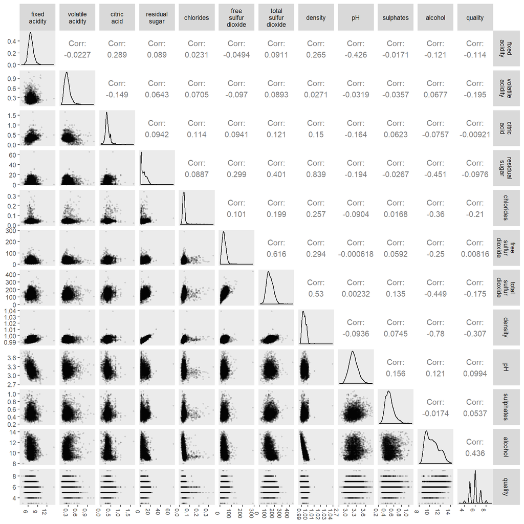

### Plot Two

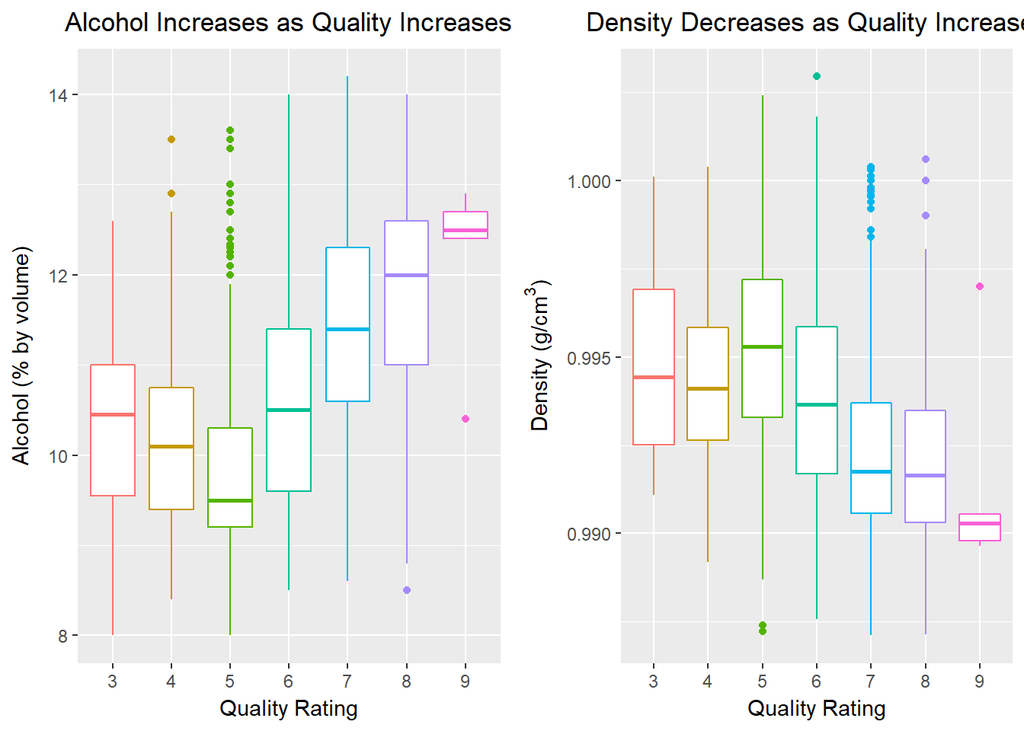